# 5. Multi-species occupancy models

## Percentage of area occupied (by species)

The `predict` function can be used to calculate Percentage of Area Occupied (PAO) for all species, optionally for a given area of interest (AOI).

For demonstration, let’s create a AOI as a simple feature (from the sf package) Normally you’d just load a shapefile or other spatial vector data set.

```r
Sr1 = st_polygon(list(cbind(c(10, 10, 30, 30, 10),
                    c(40, 70, 80, 40, 40))))
aoi <- data.frame(name = "My AOI")
st_geometry(aoi) <- st_geometry(Sr1)
```

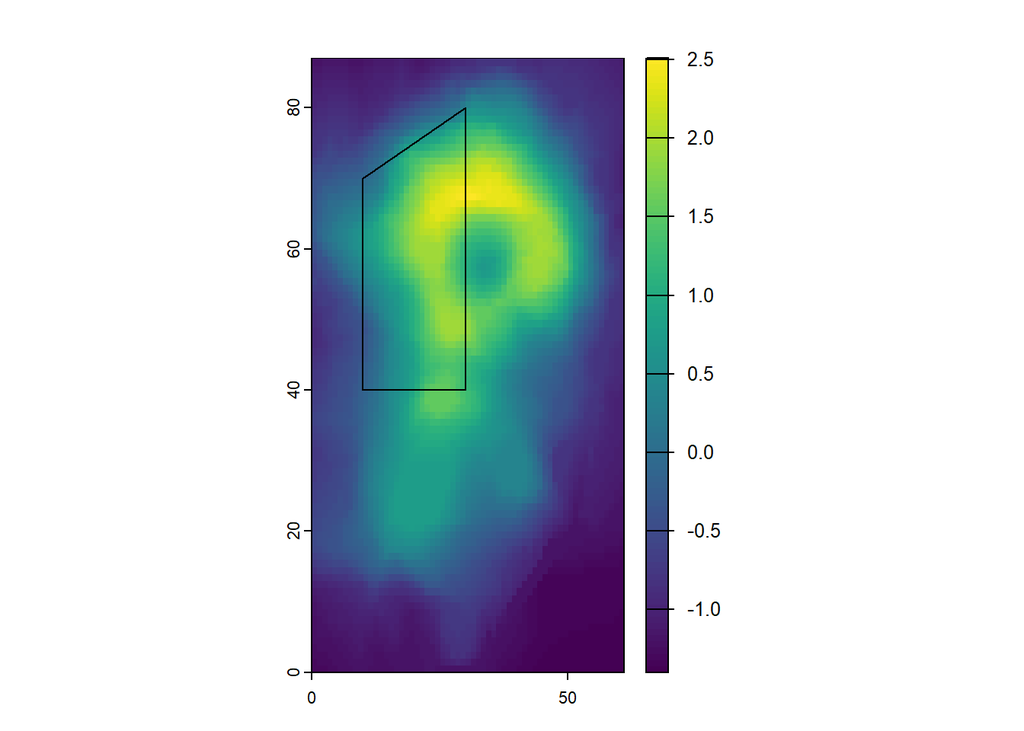

```r
plot(r_volcano)
plot(vect(aoi), add = T)   # easier plotting via SpatVect object from terra
```

To use the vector layer as an AOI, we need to rasterize it. PAO will refer to all cells in the AOI raster that are not NA.

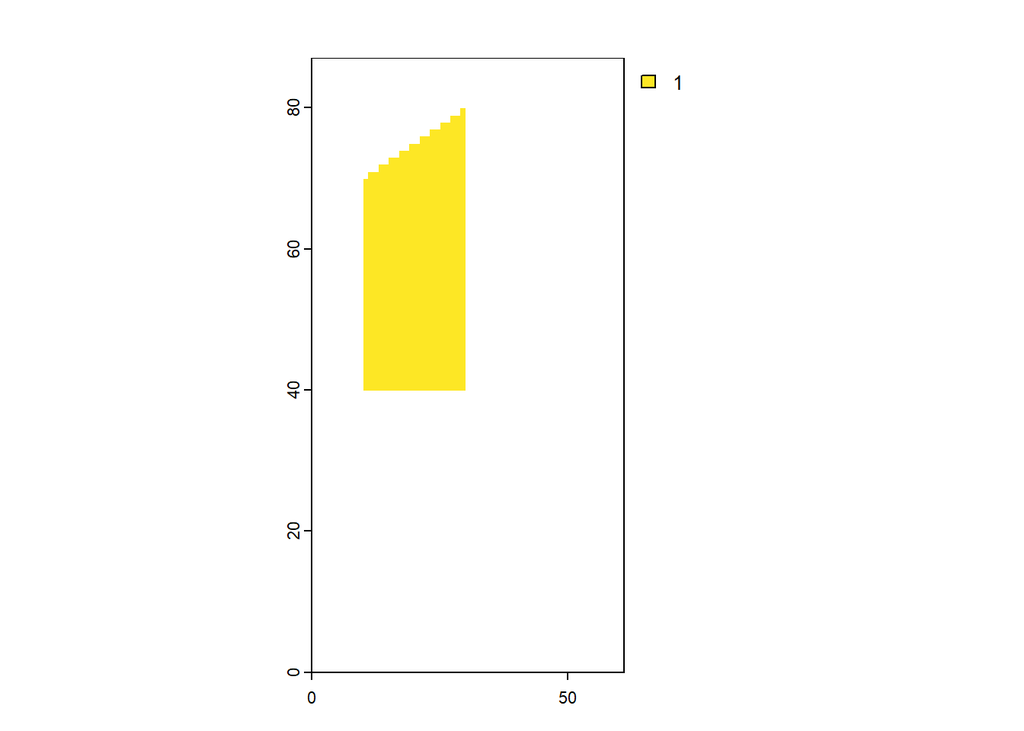

```r
r_aoi <- rasterize(aoi, r_volcano)
plot(r_aoi)
```

Now the prediction of PAO:

```r
  predictions_pao <- predict(object    = model_jags_categ3,
                             mcmc.list = out_ahm_jags_categ3,
                             x         = stack_prediction,
                             type      = "pao",
                             aoi       = r_aoi)
```

Output is a list with several components:

$pao_summary is a summary table with quantiles of predicted PAO for all species.

```r
predictions_pao$pao_summary
```

```
##       Min. lower.ci.0.025 1st Qu. Median  Mean 3rd Qu. upper.ci.0.975  Max.
## sp1  0.023          0.044   0.093  0.179 0.237   0.344          0.652 0.780
## sp2  0.021          0.037   0.116  0.214 0.260   0.359          0.677 0.837
## sp3  0.004          0.021   0.105  0.214 0.272   0.424          0.709 0.784
## sp4  0.131          0.249   0.508  0.709 0.661   0.834          0.939 0.977
## sp5  0.024          0.044   0.116  0.214 0.267   0.358          0.738 0.883
## sp6  0.209          0.337   0.647  0.786 0.734   0.879          0.953 0.979
## sp7  0.010          0.056   0.187  0.392 0.400   0.574          0.838 0.906
## sp8  0.016          0.027   0.061  0.111 0.153   0.195          0.489 0.751
## sp9  0.034          0.058   0.197  0.330 0.370   0.544          0.782 0.857
## sp10 0.011          0.019   0.056  0.088 0.129   0.172          0.419 0.581
## sp11 0.031          0.120   0.416  0.629 0.588   0.791          0.903 0.936
## sp12 0.034          0.054   0.298  0.479 0.483   0.703          0.908 0.981
## sp13 0.007          0.020   0.064  0.124 0.165   0.199          0.556 0.734
## sp14 0.071          0.113   0.291  0.566 0.524   0.729          0.910 0.956
## sp15 0.031          0.053   0.136  0.280 0.330   0.497          0.794 0.857
## sp16 0.036          0.098   0.268  0.411 0.431   0.567          0.841 0.867
## sp18 0.010          0.048   0.146  0.336 0.369   0.555          0.816 0.847
## sp19 0.009          0.042   0.122  0.312 0.338   0.508          0.819 0.881
## sp20 0.023          0.052   0.171  0.414 0.426   0.676          0.853 0.901
```

$pao_matrix contains the PAO estimates for all species from all posterior draws (not shown here)

```r
predictions_pao$pao_matrix
```

$pao_df is similar to $pao_matrix, but in a data frame in long format, ready for use in ggplot2.

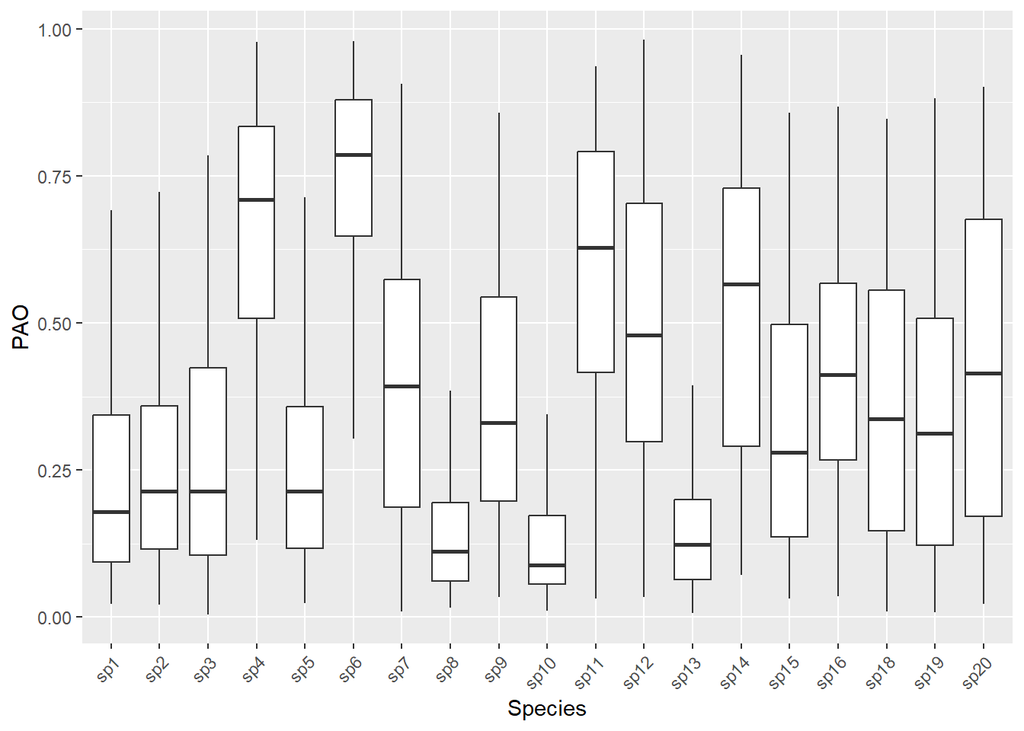

```r
  ggplot2::ggplot(predictions_pao$pao_df, aes(x = Species , y = PAO)) +
  geom_boxplot(outlier.shape = NA) +
  theme(axis.text.x = element_text(angle = 45, hjust = 1))
```

$aoi is a raster layer (SpatRaster) showing the AOI (now with cells removed that are NA in the prediction rasters)

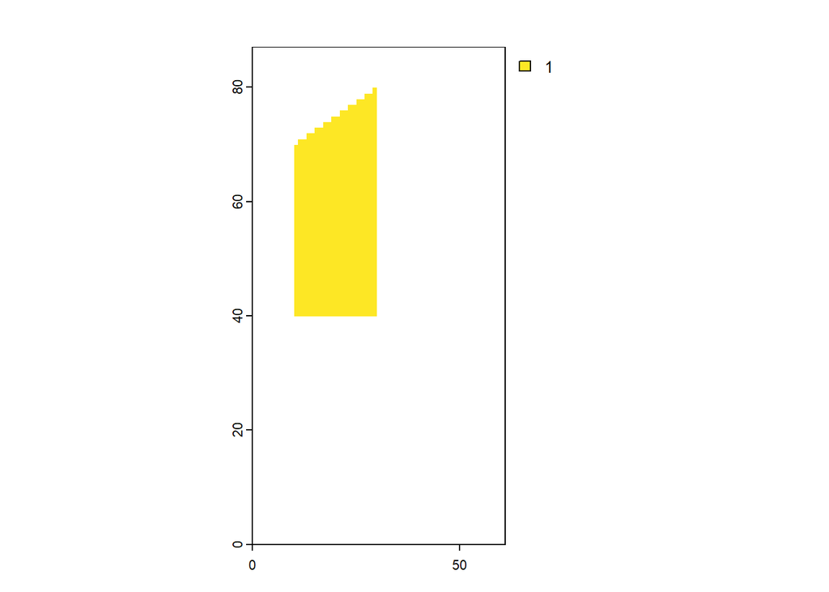

```r
plot(predictions_pao$aoi)
```

## bayesplot

We can also use the powerful bayesplot package for visualizing model estimates. One downside is that it won’t automatically insert the species names.

```r
library(bayesplot)
```

Here is an example for density plots showing the species-level effects of habitat on occupancy:

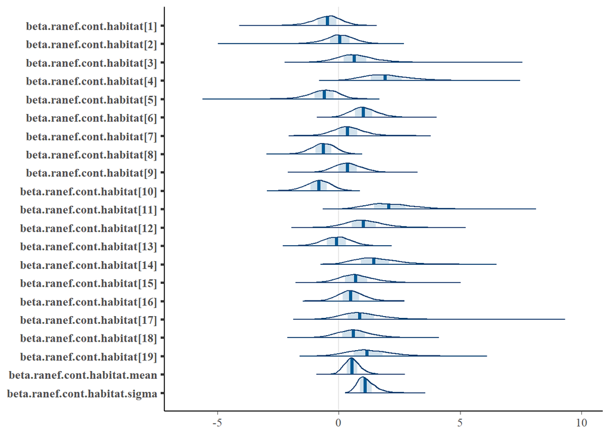

```r
mcmc_areas(out_ahm_nimble2, regex_pars = "beta.ranef.cont.habitat")
```

bayesplot has many other visualization options beyond this example. See the respective documentation, e.g. https://mc-stan.org/bayesplot/.

## Model diagnostics

Output of `fit()` is a coda::mcmc.list, so `plot()` provides traceplots (not shown here for space reasons):

```r
plot(out_ahm_nimble2)
```

The Gelman-Rubin convergence statistic (potential scale reduction factor) can be calculated with `gelman.diag()` from `coda`:

```r
gd <- coda::gelman.diag(out_ahm_nimble2,  multivariate = FALSE)
gd
```

```
## Potential scale reduction factors:
##
##                                 Point est. Upper C.I.
## alpha.obs.ranef.cont.wind[1]          1.00       1.00
## alpha.obs.ranef.cont.wind[2]          1.00       1.00
## alpha.obs.ranef.cont.wind[3]          1.00       1.00
## alpha.obs.ranef.cont.wind[4]          1.00       1.00
## alpha.obs.ranef.cont.wind[5]          1.00       1.00
## alpha.obs.ranef.cont.wind[6]          1.00       1.01
## alpha.obs.ranef.cont.wind[7]          1.00       1.00
## alpha.obs.ranef.cont.wind[8]          1.00       1.00
## alpha.obs.ranef.cont.wind[9]          1.00       1.00
## alpha.obs.ranef.cont.wind[10]         1.00       1.00
## alpha.obs.ranef.cont.wind[11]         1.00       1.00
## alpha.obs.ranef.cont.wind[12]         1.00       1.00
## alpha.obs.ranef.cont.wind[13]         1.00       1.00
## alpha.obs.ranef.cont.wind[14]         1.01       1.02
## alpha.obs.ranef.cont.wind[15]         1.00       1.00
## alpha.obs.ranef.cont.wind[16]         1.00       1.00
## alpha.obs.ranef.cont.wind[17]         1.00       1.00
## alpha.obs.ranef.cont.wind[18]         1.00       1.00
## alpha.obs.ranef.cont.wind[19]         1.00       1.01
## alpha.obs.ranef.cont.wind.mean        1.00       1.00
## alpha.obs.ranef.cont.wind.sigma       1.00       1.01
## alpha0[1]                             1.00       1.01
## alpha0[2]                             1.00       1.01
## alpha0[3]                             1.00       1.00
## alpha0[4]                             1.00       1.01
## alpha0[5]                             1.00       1.00
## alpha0[6]                             1.00       1.00
## alpha0[7]                             1.00       1.00
## alpha0[8]                             1.01       1.02
## alpha0[9]                             1.00       1.00
## alpha0[10]                            1.00       1.00
## alpha0[11]                            1.00       1.01
## alpha0[12]                            1.00       1.01
## alpha0[13]                            1.00       1.00
## alpha0[14]                            1.00       1.00
## alpha0[15]                            1.00       1.00
## alpha0[16]                            1.00       1.00
```

[output cut: 32 more lines]

```
## beta0[7]                              1.00       1.00
## beta0[8]                              1.00       1.02
## beta0[9]                              1.00       1.00
## beta0[10]                             1.00       1.00
## beta0[11]                             1.00       1.01
## beta0[12]                             1.00       1.01
## beta0[13]                             1.00       1.01
## beta0[14]                             1.00       1.00
## beta0[15]                             1.00       1.00
## beta0[16]                             1.00       1.00
## beta0[17]                             1.00       1.01
## beta0[18]                             1.00       1.00
## beta0[19]                             1.00       1.01
## beta0.mean                            1.01       1.02
## beta0.sigma                           1.00       1.02
```

One can also use `gelman.plot` to create Gelman-Rubin-Brooks plots (evolution of Gelman-Rubin statistic over iterations):

```r
# not shown here due to space reasons
coda::gelman.plot(out_ahm_nimble2,  multivariate = FALSE)
```

## Royle-Nichols model

Instead of a standard occupancy model one can fit the occupancy model of Royle and Nichols (2003), which relates probability of detection of the species to the number of individuals available for detection at each site (instead of their occupancy status alone). Probability of occupancy is a derived parameter: the probability that at least one individual is available for detection at the site. It is achieve by setting the parameter “model” to “RN”:

```r
modelFile_jags_RN <- tempfile(fileext = ".txt")

model1_jags_RN <- communityModel(
  model = "RN",
  occuCovs = list(ranef = c("habitat")),
  detCovsObservation = list(ranef = "wind"),
  intercepts = list(det = "ranef", occu = "ranef"),
  data_list = input_AHM,
  modelFile = modelFile_jags_RN)
```

```
## Site covariates may not be scaled. Scaling is strongly recommended for numeric covariates.
```

```
## Wrote model to C:\Users\Juergen\AppData\Local\Temp\RtmpENoX2m\file29609ef2645.txt
```

```r
out_ahm_jags_RN <- fit(model1_jags_RN,
                    n.iter = 5000,
                    n.burnin = 2500,
                    thin = 5,
                    chains = 3,
                    quiet = T
)
```

The models can be processed as shown before, e.g.:

Summary statistics of model parameters:

```r
DT::datatable(round(summary(out_ahm_jags_RN)$statistics, 3))
```

|  | Mean | SD | Naive SE | Time-series SE |
| --- | --- | --- | --- | --- |
| Nspecies | 19 | 0 | 0 | 0 |
| Nspecies_station[1] | 2.927 | 0.892 | 0.023 | 0.025 |
| Nspecies_station[2] | 4.007 | 0.961 | 0.025 | 0.034 |
| Nspecies_station[3] | 3.952 | 0.974 | 0.025 | 0.031 |
| Nspecies_station[4] | 4.971 | 0.967 | 0.025 | 0.033 |
| Nspecies_station[5] | 3.859 | 0.898 | 0.023 | 0.029 |
| Nspecies_station[6] | 4.078 | 1.012 | 0.026 | 0.031 |
| Nspecies_station[7] | 2.318 | 1.093 | 0.028 | 0.03 |
| Nspecies_station[8] | 3.929 | 0.931 | 0.024 | 0.03 |
| Nspecies_station[9] | 5.013 | 1.018 | 0.026 | 0.035 |

[output cut: 105 more lines]

Response curves (marginal effect plots).

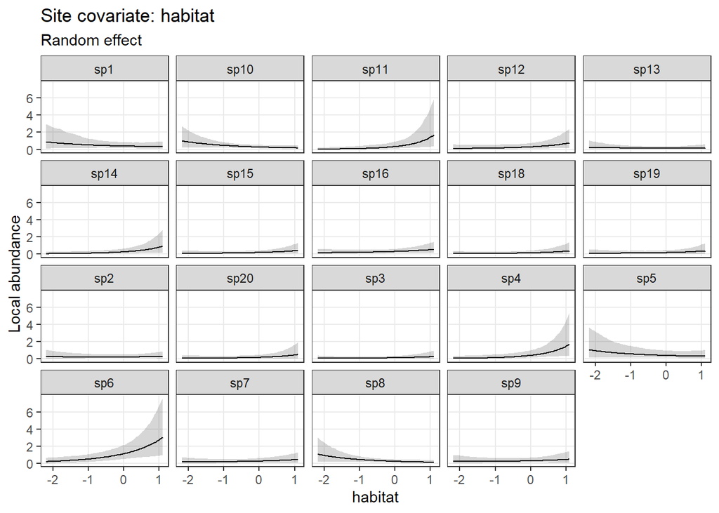

```r
# In the occupancy (state) submodel, one can show abundance (the latent quantity modelled)
plot_effects(model1_jags_RN,
             out_ahm_jags_RN,
             submodel = "state",
             response = "abundance")
```

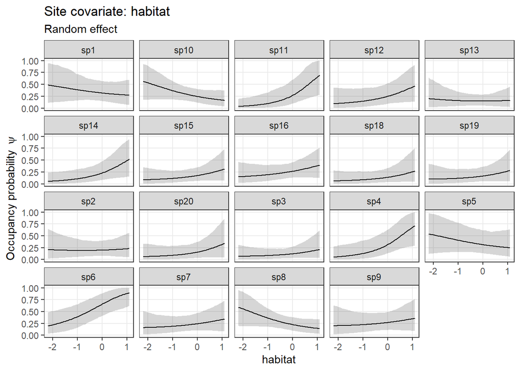

```r
# In the occupancy (state) submodel, one can also show occupancy (which is derived from abundance):
plot_effects(model1_jags_RN,
             out_ahm_jags_RN,
             submodel = "state",
             response = "occupancy")
```

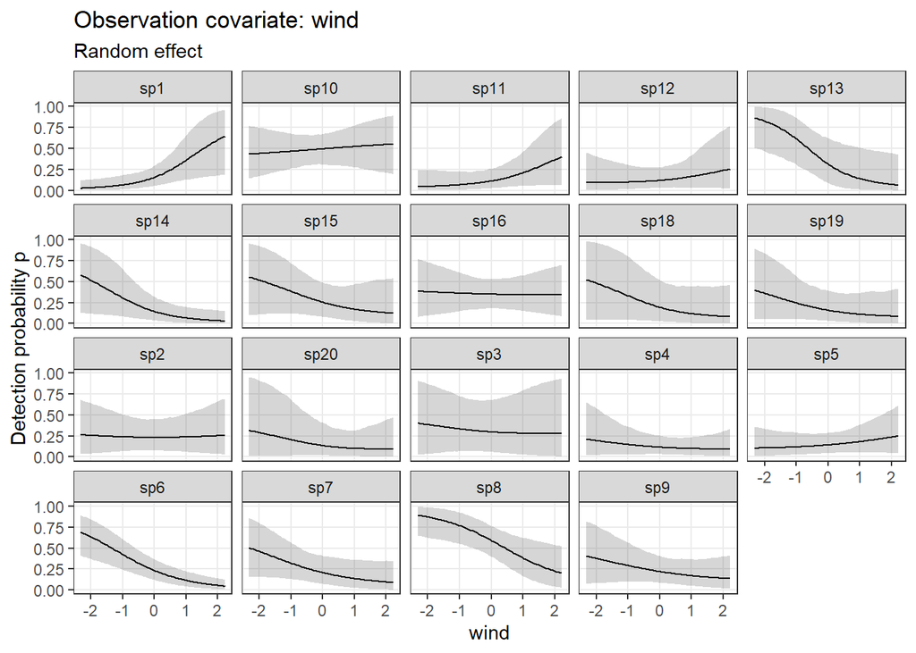

```r
plot_effects(model1_jags_RN,
             out_ahm_jags_RN,
             submodel = "det")
```

Coefficient plots:

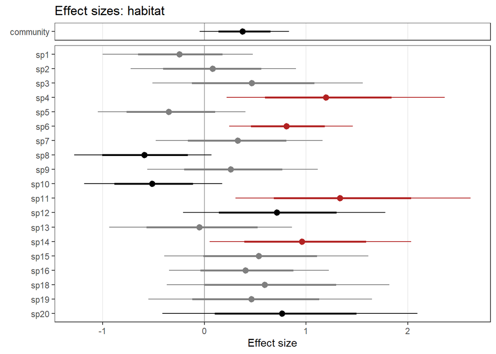

```r
plot_coef(model1_jags_RN,
          out_ahm_jags_RN,
          ordered = FALSE)
```

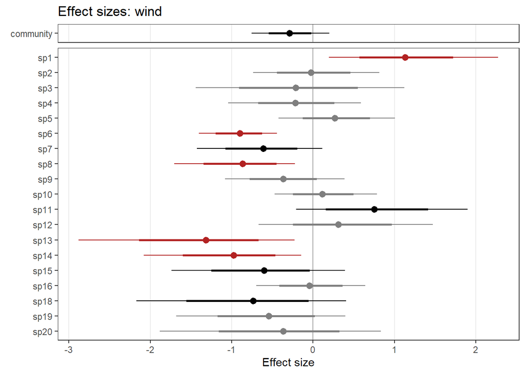

```r
plot_coef(model1_jags_RN,
          out_ahm_jags_RN,
          ordered = FALSE,
          submodel = "det")
```

Predictions work as before, but a Royle-Nichols model allows for returning expected species abundance (lambda) via type = “abundance” and type = “lambda_array”. Occupancy predictions internally convert abundance to occupancy.

Occupancy predictions (type = “psi”)

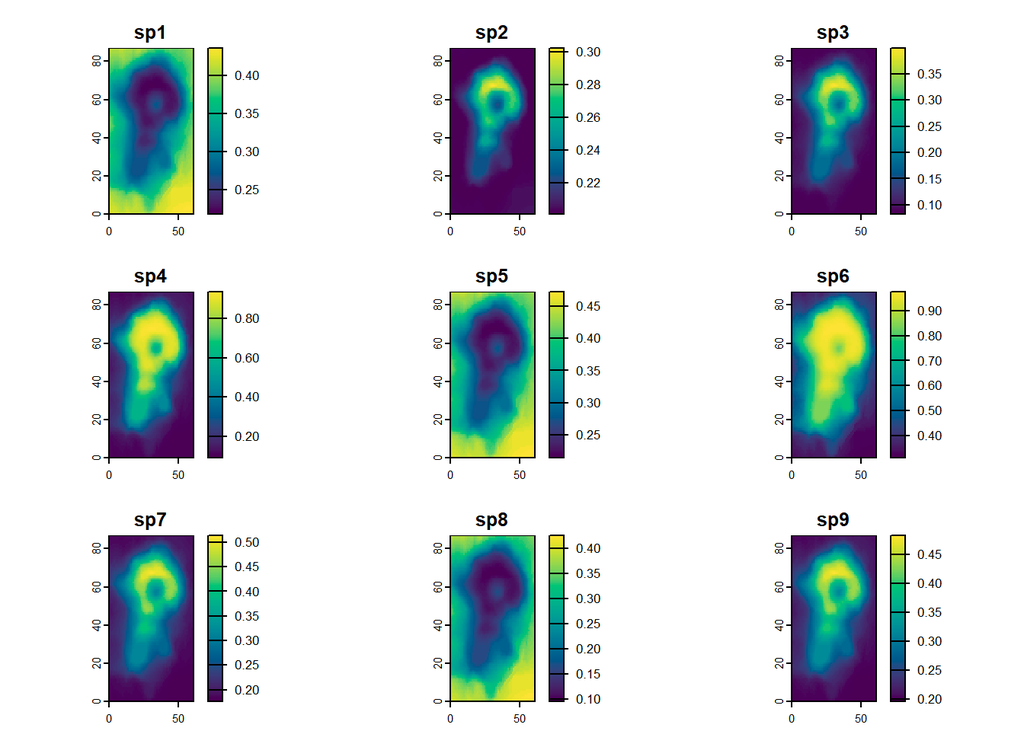

```r
predictions_psi_RN <- predict(object    = model1_jags_RN,
                             mcmc.list = out_ahm_jags_RN,
                             x         = stack_prediction,
                             type      = "psi",
                             draws     = 200)
plot(predictions_psi_RN$mean,
     col = hcl.colors(100),
       maxnl = 9)  # first 9 species only
```

Abundance predictions (type = “abundance”):

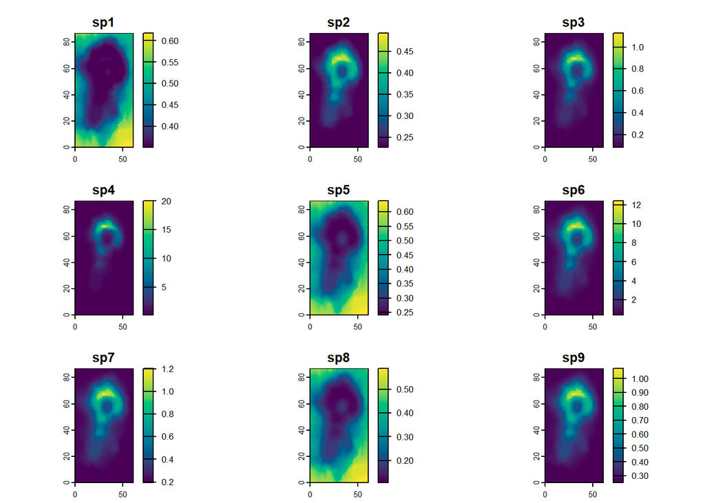

```r
predictions_abundance_RN <- predict(object    = model1_jags_RN,
                             mcmc.list = out_ahm_jags_RN,
                             x         = stack_prediction,
                             type      = "abundance",
                             draws     = 200)
plot(predictions_abundance_RN$mean,
     col = hcl.colors(100),
     maxnl = 9)   # first 9 species only
```

Richness predictions (type = “richness”)

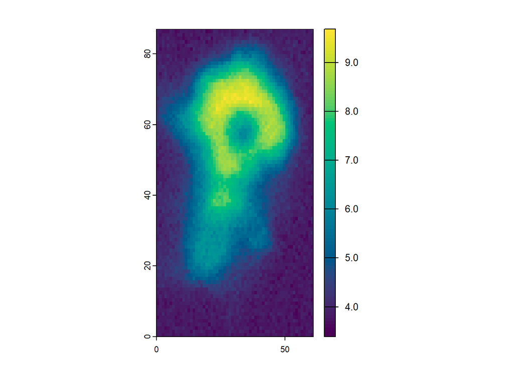

```r
  predictions_richness_RN <- predict(object    = model1_jags_RN,
                             mcmc.list = out_ahm_jags_RN,
                             x         = stack_prediction,
                             type      = "richness",
                             draws     = 200)
plot(predictions_richness_RN$mean, col = hcl.colors(100))
```

PAO predictions (type = “pao”):

```r
  predictions_pao_RN <- predict(object    = model1_jags_RN,
                             mcmc.list = out_ahm_jags_RN,
                             x         = stack_prediction,
                             type      = "pao",
                             draws     = 200)
DT::datatable(predictions_pao_RN$pao_summary)
```

|  | Min. | lower.ci.0.025 | 1st Qu. | Median | Mean | 3rd Qu. | upper.ci.0.975 | Max. |
| --- | --- | --- | --- | --- | --- | --- | --- | --- |
| sp1 | 0.129 | 0.158 | 0.26 | 0.324 | 0.336 | 0.403 | 0.573 | 0.687 |
| sp2 | 0.063 | 0.088 | 0.151 | 0.193 | 0.209 | 0.258 | 0.398 | 0.497 |
| sp3 | 0.015 | 0.051 | 0.098 | 0.137 | 0.152 | 0.201 | 0.295 | 0.681 |
| sp4 | 0.152 | 0.227 | 0.307 | 0.367 | 0.376 | 0.429 | 0.559 | 0.855 |
| sp5 | 0.068 | 0.147 | 0.237 | 0.293 | 0.32 | 0.371 | 0.665 | 0.799 |
| sp6 | 0.368 | 0.458 | 0.555 | 0.623 | 0.623 | 0.686 | 0.816 | 0.889 |
| sp7 | 0.078 | 0.112 | 0.2 | 0.252 | 0.266 | 0.322 | 0.478 | 0.624 |
| sp8 | 0.121 | 0.139 | 0.206 | 0.248 | 0.261 | 0.315 | 0.42 | 0.498 |
| sp9 | 0.057 | 0.105 | 0.212 | 0.28 | 0.276 | 0.331 | 0.464 | 0.53 |
| sp10 | 0.118 | 0.148 | 0.224 | 0.258 | 0.266 | 0.308 | 0.418 | 0.466 |

[output cut: 9 more lines]

## Single-species occupancy models

Incidentally, the workflow above can be used for single-species models too. The code will be less streamlined and possibly slower than normal code for single-species models (due to the species loop which is unnecessary for single-species models), but it is possible.

To create a single-species occupancy model, simply pass a single detection history in the data_list$ylist of the input to `communityModel`.

Take care to only define fixed effects for covariates and the intercepts, not random effects of species. It is possible however to specify random effects of categorical site covariates on continuous site covariates as in the example below.

In this example we use species 1 from the community created with `AHMbook::simComm`.

```r
input_AHM_sp1 <- list(ylist = ylist[1],    # ylist[1] is still a list, with 1 element
                      siteCovs = input_AHM$siteCovs,
                      obsCovs = input_AHM$obsCovs)
```

Create model:

```r
modelFile_jags_sp1 <- tempfile(fileext = ".txt")

model_sp1_jags_ranef <- communityModel(
  occuCovs = list(ranef = c("habitat|categ")),    # response to habitat differs between categ via random effect
  detCovsObservation = list(fixed = "wind"),
  intercepts = list(det = "fixed", occu = "fixed"),
  data_list = input_AHM_sp1,
  modelFile = modelFile_jags_sp1)
```

Fit model:

```r
fit_jags_sp1 <- fit(model_sp1_jags_ranef, n.iter = 1000, n.burnin = 500, thin = 5)
```

Print summary statistics:

```r
DT::datatable(round(summary(fit_jags_sp1)$statistics, 3))
```

|  | Mean | SD | Naive SE | Time-series SE |
| --- | --- | --- | --- | --- |
| Nspecies | 1 | 0 | 0 | 0 |
| Nspecies_station[1] | 0.8 | 0.401 | 0.023 | 0.041 |
| Nspecies_station[2] | 1 | 0 | 0 | 0 |
| Nspecies_station[3] | 0.597 | 0.491 | 0.028 | 0.061 |
| Nspecies_station[4] | 1 | 0 | 0 | 0 |
| Nspecies_station[5] | 0.58 | 0.494 | 0.029 | 0.054 |
| Nspecies_station[6] | 0.63 | 0.484 | 0.028 | 0.045 |
| Nspecies_station[7] | 0.55 | 0.498 | 0.029 | 0.054 |
| Nspecies_station[8] | 0.533 | 0.5 | 0.029 | 0.051 |
| Nspecies_station[9] | 1 | 0 | 0 | 0 |

[output cut: 29 more lines]

The `plot_effects()` and `plot_coef()` functions currently don’t work for this case, since single-species models are mostly a side-effect of the intended community occupancy workflow and not the main goal. There are other great options for Bayesian single-species occupancy models, e.g. in the packages ubms or wiqid, or unmarked for a frequentist implementation.